# Chromatin Segmentation Analysis in R

August 4, 2021

## Overview

## Overview

- A brief introduction of segmentation analysis and *ChromHMM*
- Apply the analysis to a test dataset and explore the output
- Interpret the output of the segmentation using functions from `segmenter`

## Background

## Hidden Markov Models (HMM)

- A system (process) with unobservable or hidden states can be modeled with a dependent observable process.
- The chromatin configurations are the hidden states modeled using histone markers that are associated with these configurations.

[figure not shown]

Figure 1. Probabilistic parameters of a hidden Markov model. X — states, Y — possible observations, a — state transition probabilities and b — output. (Wikipedia)

## ChromHMM

- *ChromHmm* is a Java program to learn chromatin states from multiple sets of ChIP-seq histone markers.
- States are modeled as the combination of markers on the different regions of the genome.
- A multi-variate hidden Markov model is used to model the presence or absence of the markers.
- The combination of histone markers at a given location is interpreted as a biological state.
- Ref: [Ernst, J., Kellis, M. Chromatin-state discovery and genome annotation with ChromHMM. Nat Protoc 12, 2478–2492 (2017).](https://doi.org/10.1038/nprot.2017.124)

## This package!

The goal of the `segmenter` package is to

- Call *ChromHMM* using R syntax
- Capture the output in R objects
- Interact with the model output for the purposes of summarizing or visualizing

## Getting Started

## Installation

The package can be installed from Bioconductor using `BiocManager` or from GitHub using `remotes`

```r
# install from bioconductor (3.14)
BiocManager::install('segmenter')

# install from github
remotes::install_github('MahShaaban/segmenter@devel')
```

## Example code

```r
# learn chromatin model
obj <- learn_model(
    inputdir = <input binarized files>,
    coordsdir = <genomic coordinates of features>,
    anchorsdir = <genomic location of TSS>,
    chromsizefile = <chromosome lengths>,
    numstates = <the number of desired states>,
    assembly = <the genome assembly>,
    cells = <names of the biological samples>,
    annotation = <name of the reference genome type>,
    binsize = <the size of bins>
)
```

## Using `segmenter`

*ChromHMM* requires two types of input files. Those are

- Genomic annotation files
  - Coordinates: the start and end location of genomic features to calculate enrichment
  - Anchors: the transcription start and end sites
  - Chromosome size: the length of each chromosome
- Binarized signal files from the ChIP-seq data

### Genomic annotation files

```r
# coordinates
coordsdir <- 'hg38_coords'
list.files(coordsdir)
```

```
#> [1] "CpGIsland.hg38.bed.gz"    "RefSeqExon.hg38.bed.gz"
#> [3] "RefSeqGene.hg38.bed.gz"   "RefSeqTES.hg38.bed.gz"
#> [5] "RefSeqTSS.hg38.bed.gz"    "RefSeqTSS2kb.hg38.bed.gz"
```

```r
# anchors
anchorsdir <- 'hg38_anchors'
list.files(anchorsdir)
```

```
#> [1] "RefSeqTES.hg38.txt.gz" "RefSeqTSS.hg38.txt.gz"
```

```r
# chromosomes' sizes
chromsizefile <- 'hg38_chromsizes.txt'
read.delim(chromsizefile, header = FALSE, nrows = 2)
```

```
#>     V1        V2
#> 1 chr1 248956422
#> 2 chr2 242193529
```

### Binarized signal files from the ChIP-seq data

- The binarized signal files are text files, often one for each chromosome
- Data is divided into bins of a given size (rows) and have binary values 1 (> threshold) or 0 for each histone marker (columns)
- From bam `binarize_bam` or bed `binarize_bed`

```r
# a table to assign marker and cell names to the bam files
cell_marks <- 'cell_mark_file.tsv'
read.delim(cell_marks, header = FALSE, nrows = 3)
```

```
#>        V1       V2              V3
#> 1 GM12878 H3K27me3 ENCFF796DDM.bam
#> 2 GM12878 H3K27me3 ENCFF927XRX.bam
#> 3 GM12878 H3K27me3 ENCFF265UBT.bam
```

```r
# run command
binarize_bam('bam/',
             chromsizefile = chromsizefile,
             cell_marks = cell_marks,
             outputdir = 'bins_200')
```

```r
# show output files
example_binaries <- list.files('bins_200', full.names = TRUE)[1]
read.delim(example_binaries, nrows = 2, skip = 1)
```

```
#>   H2AFZ H3K27ac H3K27me3 H3K36me3 H3K4me1 H3K4me2 H3K4me3 H3K79me2 H3K9ac
#> 1     0       0        0        0       0       0       0        0      0
#> 2     0       0        0        0       0       0       0        0      0
#>   H3K9me3 H4K20me1
#> 1       0        0
#> 2       0        0
```

## Model Learning

`learn_model` wraps the the Java module that learns a chromatin segmentation model of a given number of states.

```r
# load library
library(segmenter)

# run the main command
obj <- learn_model(
    inputdir = 'bins_200',
    outputdir = 'models/model_10',
    anchorsdir = 'hg38_anchors/',
    coordsdir = 'hg38_coords/',
    chromsizefile = 'hg38_chromsizes.txt',
    numstates = 10,
    cells = c('GM12878', 'H1', 'HepG2', 'IMR-90', 'K562'),
    assembly = 'hg38',
    annotation = 'RefSeq',
    binsize = 200
)
```

## Output

```r
# show the object
class(obj)
```

```
#> [1] "segmentation"
#> attr(,"package")
#> [1] "segmenter"
```

- `model`: the initial and final parameters
- `emission`: the probabilities of the mark in a given state
- `transition`: the probabilities of the states transitions
- `overlap`: the enrichment of the states at genomic features
- `TSS`: the enrichment of the states around the TSS
- `TES`: the enrichment of the states around the TES
- `segment`: the assignment of states to the bins

### Accessors

An accessor function with the same of every slot access its contents. For example, to access the emission probabilities, call `emission`

```r
# access object slots
emission(obj)
```

Some accessors have more arguments to subset the object. For example, the `segment` method take a `cell` name to return only the segments in the corresponding cell.

```r
# subset the segment slot
segment(obj, cell = 'K562')
```

### Methods

```r
# show the object
show(obj)
```

```
#> # An object of class 'segmentation'
#> # Contains a chromatin segmentation model:
#> ## States: 1 2 3 4 5 6 7 8 9 10
#> ## Marks: H3K36me3 H4K20me1 H3K79me2 H3K4me1 H3K27ac H3K9ac H3K4me2 H3K4me3 H2AFZ H3K27me3 H3K9me3
#> ## Cells: GM12878 H1 HepG2 IMR-90 K562
#> # Contains nine slots:
#> ## model: use 'model(object)' to access
#> ## emission: use 'emission(object)' to access
#> ## transition: use 'transition(object)' to access
#> ## overlap: use 'overlap(object)' to access
#> ## TSS: use 'TSS(object)' to access
#> ## TES: use 'TES(object)' to access
#> ## segment: use 'segment(object)' to access
#> ## bins: use 'bins(object)' to access
#> ## counts: use 'counts(object)' to access
#> # For more info about how to use the object, use ?accessors
```

## Interpreting the model output

## Emission and transition

- Emission is the frequency of a particular histone mark in a given chromatin state.
- Transition is the frequency by which a state (rows) transitions to another (column).
- These probabilities capture the spatial relationships between the markers (emission) and the states (transition).

```r
# access object slots
emission(obj)
transition(obj)
```

- The `plot_heatmap` takes a `segmentation` object and visualize the slot in `type`. By default, this is `emission`.
- The output is a `Heatmap` object from the `ComplexHeatmap` package. These objects can be customized to produce diverse informative figures.

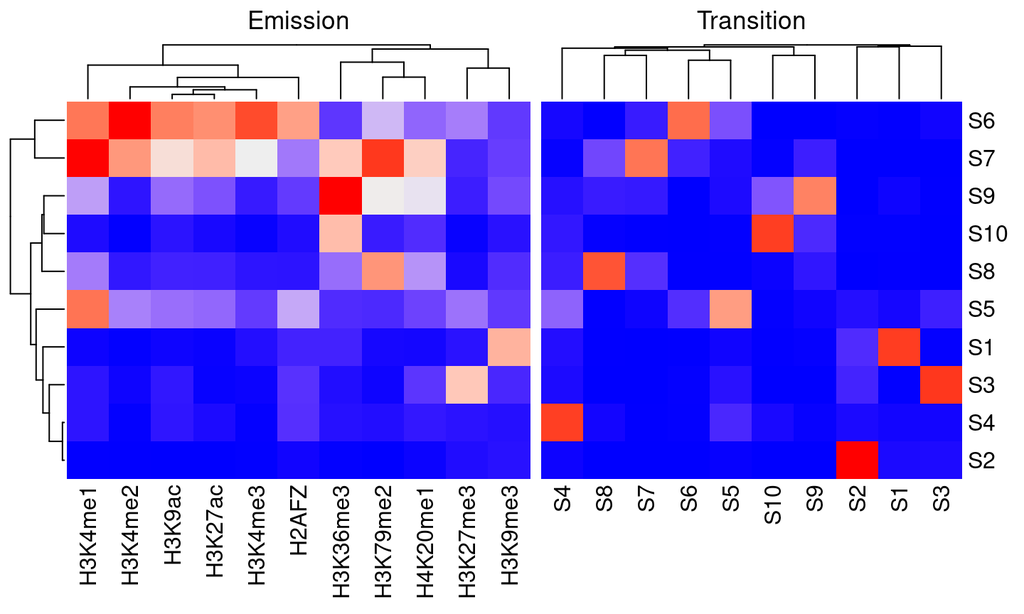

Emission and Transition

```r
# emission and transition plots
plot_heatmap(obj,
             row_labels = paste0('S', 1:10),
             name = 'Emission')

plot_heatmap(obj,
             type = 'transition',
             row_labels = paste0('S', 1:10),
             column_labels = paste0('S', 1:10),
             name = 'Transition')
```

## Enrichment

- The `overlap` slot contains the fold enrichment of each state in the genomic coordinates.
- Calculated by first dividing the number of bases in a state and an annotation and the number of bases in an annotation and in the genome.

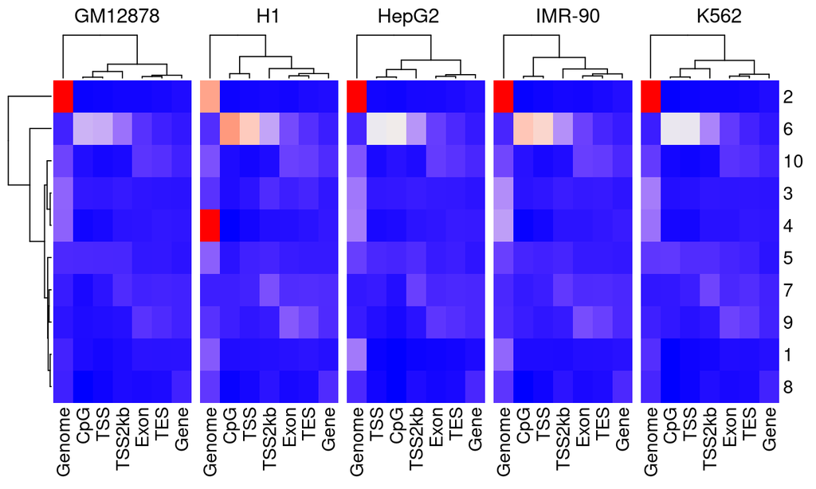

Overlap Enrichment

```r
# overlap enrichment
plot_heatmap(
    obj,
    type = 'overlap',
    column_labels = c('Genome', 'CpG', 'Exon', 'Gene',
                      'TES', 'TSS', 'TSS2kb')
)
```

## Segments

- `segment` contains the state assignment
- For each cell/condition, a `GRanges` object with the chromosome name, start and end sites in the ranges part of the object and the name of the state in a metadata column.

```r
# get segments of all cells
segment(obj)

# get segments of GM12878
segment(obj, 'GM12878')
```

```r
# get segments
segment(obj, 'GM12878')
```

```
#> $GM12878
#> GRanges object with 748339 ranges and 1 metadata column:
#>            seqnames            ranges strand |       state
#>               <Rle>         <IRanges>  <Rle> | <character>
#>        [1]    chr10           0-73800      * |          E2
#>        [2]    chr10       73800-74200      * |          E5
#>        [3]    chr10       74200-76200      * |          E4
#>        [4]    chr10       76200-76800      * |          E5
#>        [5]    chr10       76800-79000      * |          E4
#>        ...      ...               ...    ... .         ...
#>   [748335]     chrY 56851800-56855200      * |          E2
#>   [748336]     chrY 56855200-56859200      * |          E1
#>   [748337]     chrY 56859200-56868600      * |          E2
#>   [748338]     chrY 56868600-56874600      * |          E1
#>   [748339]     chrY 56874600-57227400      * |          E2
#>   -------
#>   seqinfo: 179 sequences from an unspecified genome; no seqlengths
```

```r
# load libraries
library(TxDb.Hsapiens.UCSC.hg38.knownGene)
library(GenomicRanges)

# gene gene coordinates
txdb <- TxDb.Hsapiens.UCSC.hg38.knownGene
gen <- genes(txdb, filter = list(gene_id = 38))

# extend genomic region
prom <- promoters(gen, upstream = 10000, downstream = 10000)
```

- We then used `Gviz`’s `AnnotationTrack` to render the ranges as tracks grouped by the `state` column in the `GRanges` object for each of the cell lines.

```r
# load libraries
library(Gviz)
library(IRanges)

# annotation track
tracks <- mapply(function(obj, name) {
    ## subset segments to the promoter region
    seg <- subsetByOverlaps(obj, prom)

    ## make annotation track
    AnnotationTrack(seg,
                    group = seg$state,
                    name = name)
}, segment(obj), cells(obj))
```

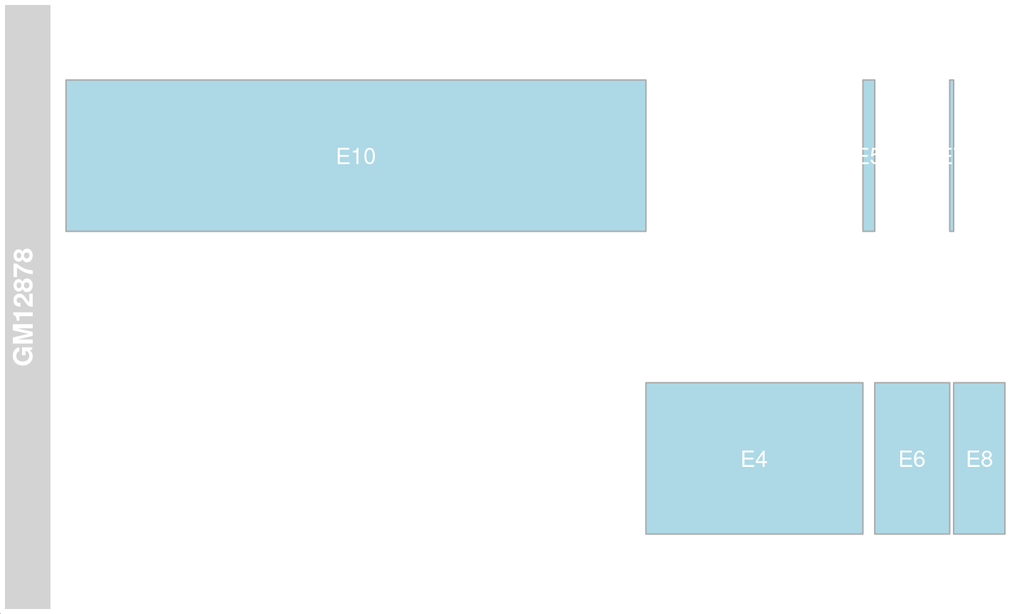

GM12878 segmentation track

```r
# plot the track for the GM12878 cells
plotTracks(tracks$GM12878, featureAnnotation = 'state')
```

Other tracks can be added to the plot to make it more informative. Here, we used

- `IdeogramTrack` to show a graphic representation of chromosome 11
- `GenomeAxisTrack` to show a scale of the exact location on the chromosome
- `GeneRegionTrack` to show the exon, intron and transcripts of the target gene

```r
# ideogram track
itrack <- IdeogramTrack(genome = 'hg38', chromosome = 11)

# genome axis track
gtrack <- GenomeAxisTrack()

# gene region track
grtrack <- BiomartGeneRegionTrack(genom = 'hg38',
                                  symbol = 'ACAT1',
                                  name = 'ACAT1')
```

Those can be put together in one plot using `plotTracks`

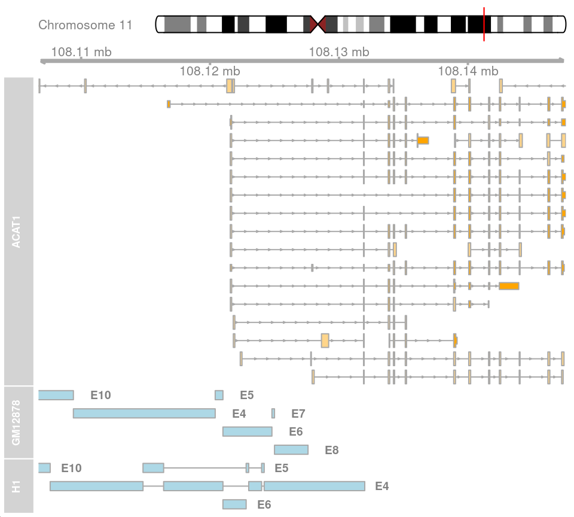

GM12878 and H1 segmentation tracks

```r
# put all tracks together
plotTracks(
    list(itrack,
         gtrack,
         grtrack,
         tracks$GM12878, tracks$H1),
    from = min(start(prom)),
    to = max(end(gen)),
    groupAnnotation = 'group',
    just.group = 'right'
)
```

- Moreover, we can summarize the segmentation output in different ways to either show how the combination of chromatin markers are arranged or to compare different cells and conditions.
- One simple summary, is to count the occurrence of states across the genome. `get_frequency` does that and returns the output in tabular or graphic formats.

```r
# get segment frequency
freq <- get_frequency(segment(obj), tidy = TRUE)
head(freq)
```

```
#>   state frequency    cell
#> 1    E1     39265 GM12878
#> 2   E10     44178 GM12878
#> 3    E2    134265 GM12878
#> 4    E3    110055 GM12878
#> 5    E4    130492 GM12878
#> 6    E5    131189 GM12878
```

The frequency of the states in each cell can also be normalized by the total number of states.

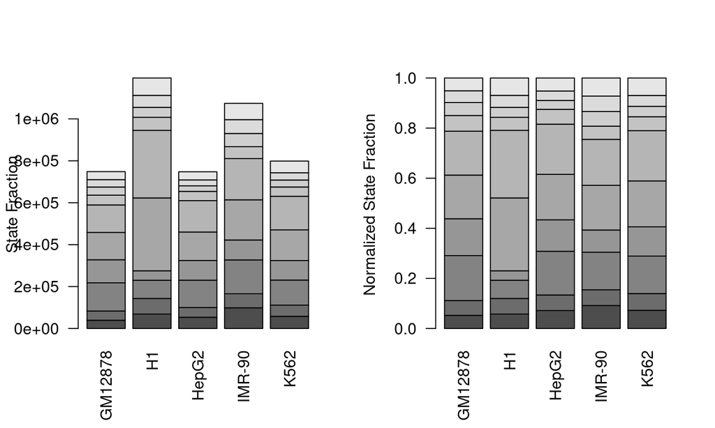

State frequency

```r
# frequency plots
par(mfrow=c(1,2))
get_frequency(segment(obj),
              plot = TRUE,
              ylab = 'State Fraction', las = 2)

get_frequency(segment(obj),
              normalize = TRUE,
              plot = TRUE,
              ylab = 'Normalized State Fraction', las = 2)
```